# Machine Learning Project

Mike Keyes

June 2, 2017

## Machine Learning Project

### Introduction

The goal of this project is to use the Weight Lifting Exercise Dataset to create a model which can predict how a person instrumented with motion sensors is doing a weight lifting curl. From the assignment background:

> Using devices such as Jawbone Up, Nike FuelBand, and Fitbit it is now possible to collect a large amount of data about personal activity relatively inexpensively. These type of devices are part of the quantified self movement - a group of enthusiasts who take measurements about themselves regularly to improve their health, to find patterns in their behavior, or because they are tech geeks. One thing that people regularly do is quantify how much of a particular activity they do, but they rarely quantify how well they do it. In this project, your goal will be to use data from accelerometers on the belt, forearm, arm, and dumbell of 6 participants. They were asked to perform barbell lifts correctly and incorrectly in 5 different ways. More information is available from the website here: http://groupware.les.inf.puc-rio.br/har (see the section on the Weight Lifting Exercise Dataset).

### Methodology

In order to achieve the goal we will perform these steps: - Load the caret package - Download the raw data from the source - Clean the data - Split the training data into train, test and validation data sets - Check for outliers - Train several models on the training data set. - Pick the best models based on accuracy with the training data set - Run these models against the Test data set to pick the best one. - Run the winner against the Validation data set to measure the final accuracy.

## Data Load and Preparation

First Load caret package:

```r
library(caret)
```

### Load Data

Download data from the source and read it into training and test data sets. Load blank values as NA:

```r
download.file('https://d396qusza40orc.cloudfront.net/predmachlearn/pml-training.csv', 'pml-training.csv')
trainRaw<-read.csv('pml-training.csv', header=TRUE, na.strings=c('','NA'))
download.file('https://d396qusza40orc.cloudfront.net/predmachlearn/pml-testing.csv', 'pml-testing.csv')
testRaw<-read.csv('pml-testing.csv', header=TRUE, na.strings=c('','NA'))
```

### Data Cleaning

Many of the columns are very sparsely populated. Remove any column with more than 50% NAs:

```r
trainRaw<- trainRaw[,colMeans(is.na(trainRaw)) <= 0.5 ]
StandardTest<- testRaw[,colMeans(is.na(testRaw)) <= 0.5 ]
```

Check for near zero variance variables. These variables will be of limited usefulness when generating models.

```r
nearZeroVar(trainRaw,saveMetrics=TRUE)
```

```
##                      freqRatio percentUnique zeroVar   nzv
## X                     1.000000  100.00000000   FALSE FALSE
## user_name             1.100679    0.03057792   FALSE FALSE
## raw_timestamp_part_1  1.000000    4.26562022   FALSE FALSE
## raw_timestamp_part_2  1.000000   85.53154622   FALSE FALSE
## cvtd_timestamp        1.000668    0.10192641   FALSE FALSE
## new_window           47.330049    0.01019264   FALSE  TRUE
## num_window            1.000000    4.37264295   FALSE FALSE
## roll_belt             1.101904    6.77810621   FALSE FALSE
## pitch_belt            1.036082    9.37722964   FALSE FALSE
## yaw_belt              1.058480    9.97349913   FALSE FALSE
## total_accel_belt      1.063160    0.14779329   FALSE FALSE
## gyros_belt_x          1.058651    0.71348486   FALSE FALSE
## gyros_belt_y          1.144000    0.35164611   FALSE FALSE
## gyros_belt_z          1.066214    0.86127816   FALSE FALSE
## accel_belt_x          1.055412    0.83579655   FALSE FALSE
## accel_belt_y          1.113725    0.72877383   FALSE FALSE
## accel_belt_z          1.078767    1.52379982   FALSE FALSE
## magnet_belt_x         1.090141    1.66649679   FALSE FALSE
## magnet_belt_y         1.099688    1.51870350   FALSE FALSE
## magnet_belt_z         1.006369    2.32901845   FALSE FALSE
## roll_arm             52.338462   13.52563449   FALSE FALSE
## pitch_arm            87.256410   15.73234125   FALSE FALSE
## yaw_arm              33.029126   14.65701763   FALSE FALSE
## total_accel_arm       1.024526    0.33635715   FALSE FALSE
## gyros_arm_x           1.015504    3.27693405   FALSE FALSE
## gyros_arm_y           1.454369    1.91621649   FALSE FALSE
## gyros_arm_z           1.110687    1.26388747   FALSE FALSE
## accel_arm_x           1.017341    3.95984099   FALSE FALSE
## accel_arm_y           1.140187    2.73672409   FALSE FALSE
## accel_arm_z           1.128000    4.03628580   FALSE FALSE
## magnet_arm_x          1.000000    6.82397309   FALSE FALSE
## magnet_arm_y          1.056818    4.44399144   FALSE FALSE
## magnet_arm_z          1.036364    6.44684538   FALSE FALSE
## roll_dumbbell         1.022388   84.20650290   FALSE FALSE
## pitch_dumbbell        2.277372   81.74498012   FALSE FALSE
## yaw_dumbbell          1.132231   83.48282540   FALSE FALSE
## total_accel_dumbbell  1.072634    0.21914178   FALSE FALSE
## gyros_dumbbell_x      1.003268    1.22821323   FALSE FALSE
## gyros_dumbbell_y      1.264957    1.41677709   FALSE FALSE
## gyros_dumbbell_z      1.060100    1.04984201   FALSE FALSE
## accel_dumbbell_x      1.018018    2.16593619   FALSE FALSE
## accel_dumbbell_y      1.053061    2.37488533   FALSE FALSE
## accel_dumbbell_z      1.133333    2.08949139   FALSE FALSE
## magnet_dumbbell_x     1.098266    5.74864948   FALSE FALSE
## magnet_dumbbell_y     1.197740    4.30129447   FALSE FALSE
## magnet_dumbbell_z     1.020833    3.44511263   FALSE FALSE
## roll_forearm         11.589286   11.08959331   FALSE FALSE
## pitch_forearm        65.983051   14.85577413   FALSE FALSE
## yaw_forearm          15.322835   10.14677403   FALSE FALSE
## total_accel_forearm   1.128928    0.35674243   FALSE FALSE
## gyros_forearm_x       1.059273    1.51870350   FALSE FALSE
## gyros_forearm_y       1.036554    3.77637346   FALSE FALSE
## gyros_forearm_z       1.122917    1.56457038   FALSE FALSE
## accel_forearm_x       1.126437    4.04647844   FALSE FALSE
## accel_forearm_y       1.059406    5.11160942   FALSE FALSE
## accel_forearm_z       1.006250    2.95586586   FALSE FALSE
## magnet_forearm_x      1.012346    7.76679238   FALSE FALSE
## magnet_forearm_y      1.246914    9.54031189   FALSE FALSE
## magnet_forearm_z      1.000000    8.57710733   FALSE FALSE
## classe                1.469581    0.02548160   FALSE FALSE
```

Only the new_window column has low variation.

We will remove timestamp, name and new_window columns. It is not clear from the data source discussion if the timestamps are meaningful. For the purposes of this exercise we will assume that they are not. The index column (column 1) will also be removed because the index of the 20 row test data set does not seem to be related to the index in the training data set.

```r
StandardTest<- StandardTest[,-c(1,2,3,4,5,6)]
trainRaw<-trainRaw[,-c(1,2,3,4,5,6)]
```

## Split Data

Create test, train and validation data sets from main Train dataset

```r
inTrain<-createDataPartition(y=trainRaw$classe, p=0.7,list=FALSE)
train<-trainRaw[inTrain,]
testFull<-trainRaw[-inTrain,]
inTest<-createDataPartition(y=testFull$classe, p=0.5,list=FALSE)
test<-testFull[inTest,]
validation<-testFull[-inTest,]
```

### Check for outliers

Check if there are obvious outliers by creating a box plot on the scaled factors:

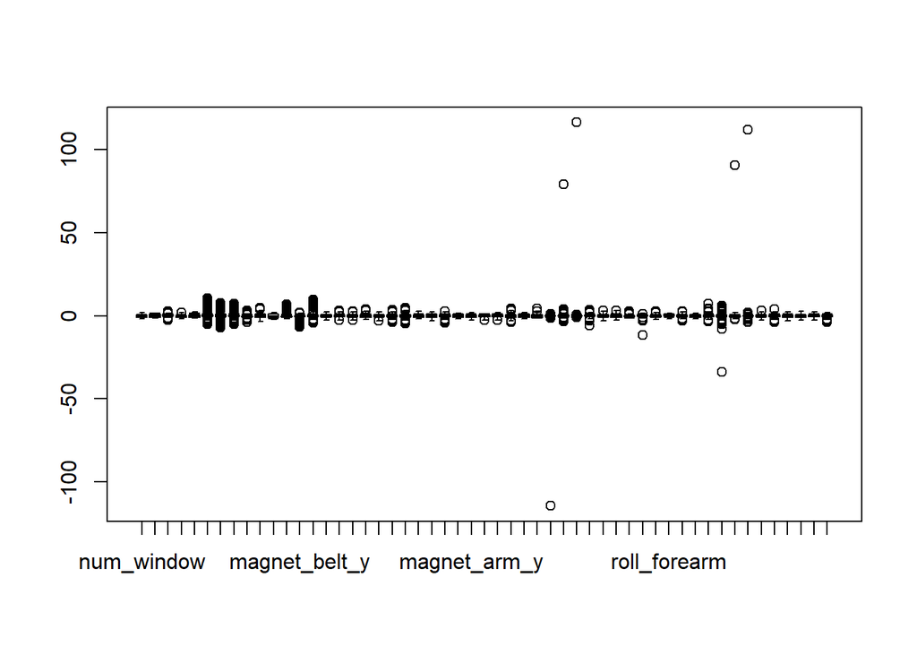

```r
trainCS <- scale(train[,-ncol(train)])
boxplot(trainCS)
```

There are a few outliers, but not many.

How many are there? Calculate the percentage of outliers more than 2 standard deviations from the mean, and how many are more than 10 SD from the meain:

```r
sum(abs(trainCS)>2)/(dim(trainCS)[1]*dim(trainCS)[2])
```

```
## [1] 0.03468116
```

```r
sum(abs(trainCS)>10)
```

```
## [1] 8
```

## Model Creation

```r
fitRF<-train(classe~.,data=train,method="rf",preProcess="pca")
```

```r
fitRFCenter<-train(classe~.,data=train,method="rf",preProcess=c("center","scale"))
fitGBMCenter<-train(classe~.,data=train,method="gbm",preProcess=c("center","scale"))
```

```r
fitLDACenter<-train(classe~.,data=train,method="lda",preProcess=c("center","scale"))
```

Cross validation of each model will be done using the test data set. The model with the best accuracy will be chosen as the winner.

### Random Forest with PCA pre-processing

```r
confusionMatrix(test$classe, predict(fitRF, test))$overall
```

```
##       Accuracy          Kappa  AccuracyLower  AccuracyUpper   AccuracyNull
##      0.9745158      0.9677621      0.9681589      0.9799035      0.2857628
## AccuracyPValue  McnemarPValue
##      0.0000000            NaN
```

### Random Forest with Center and Scale pre-processing

```r
confusionMatrix(test$classe, predict(fitRFCenter, test))$overall
```

```
##       Accuracy          Kappa  AccuracyLower  AccuracyUpper   AccuracyNull
##      0.9983011      0.9978508      0.9960397      0.9994481      0.2854230
## AccuracyPValue  McnemarPValue
##      0.0000000            NaN
```

### GBM with Center and scale pre-processing

```r
confusionMatrix(test$classe, predict(fitGBMCenter, test))$overall
```

```
##       Accuracy          Kappa  AccuracyLower  AccuracyUpper   AccuracyNull
##      0.9850493      0.9810870      0.9799808      0.9891163      0.2857628
## AccuracyPValue  McnemarPValue
##      0.0000000            NaN
```

### Linear Discriminant Analysis with Center and scale pre-processing

```r
confusionMatrix(test$classe, predict(fitLDACenter, test))$overall
```

```
##       Accuracy          Kappa  AccuracyLower  AccuracyUpper   AccuracyNull
##   7.149168e-01   6.394896e-01   6.982283e-01   7.311769e-01   2.898403e-01
## AccuracyPValue  McnemarPValue
##   0.000000e+00   3.887907e-25
```

### Model Choice

The Random Forest with centering and scaling pre-processing model has the best accuracy. fitRFCenter will be used going forward.

## Final Validation

The fitRFCenter model will be run against the Validation data set to get estimates of its accuracy:

```r
confusionMatrix(validation$classe, predict(fitRFCenter, validation))
```

```
## Confusion Matrix and Statistics
##
##           Reference
## Prediction   A   B   C   D   E
##          A 837   0   0   0   0
##          B   3 565   1   0   0
##          C   0   0 513   0   0
##          D   0   0   0 482   0
##          E   0   1   0   1 539
##
## Overall Statistics
##
##                Accuracy : 0.998
##                  95% CI : (0.9956, 0.9993)
##     No Information Rate : 0.2855
##     P-Value [Acc > NIR] : < 2.2e-16
##
##                   Kappa : 0.9974
##  Mcnemar's Test P-Value : NA
##
## Statistics by Class:
##
##                      Class: A Class: B Class: C Class: D Class: E
## Sensitivity            0.9964   0.9982   0.9981   0.9979   1.0000
## Specificity            1.0000   0.9983   1.0000   1.0000   0.9992
## Pos Pred Value         1.0000   0.9930   1.0000   1.0000   0.9963
## Neg Pred Value         0.9986   0.9996   0.9996   0.9996   1.0000
## Prevalence             0.2855   0.1924   0.1747   0.1642   0.1832
## Detection Rate         0.2845   0.1920   0.1744   0.1638   0.1832
## Detection Prevalence   0.2845   0.1934   0.1744   0.1638   0.1839
## Balanced Accuracy      0.9982   0.9983   0.9990   0.9990   0.9996
```

Finally, it can be run against the StandardTest data set to provide answers for the quiz:

```r
predict(fitRFCenter, StandardTest)
```

```
##  [1] B A B A A E D B A A B C B A E E A B B B
## Levels: A B C D E
```

These 20 predictions were all correct.